# Student Demographics and Final Grades

CIS 351 Final Project

Authors

## 2 Loading packages and data

```r
library(tidyverse)

library(janitor)

library(ucimlrepo)

library(ggpubr)

library(car)

library(skimr)

library(gt)

uci_df <- fetch_ucirepo(name = 'Student Performance')

df <- uci_df$data$original |>
    clean_names()
```

## 3 Exploratory Data Analysis Using `skim()`

```r
skim(df)
```

Data summary

| Name | df |
| --- | --- |
| Number of rows | 649 |
| Number of columns | 33 |
| _______________________ |  |
| Column type frequency: |  |
| character | 17 |
| numeric | 16 |
| ________________________ |  |
| Group variables | None |

**Variable type: character**

| skim_variable | n_missing | complete_rate | min | max | empty | n_unique | whitespace |
| --- | --- | --- | --- | --- | --- | --- | --- |
| school | 0 | 1 | 2 | 2 | 0 | 2 | 0 |
| sex | 0 | 1 | 1 | 1 | 0 | 2 | 0 |
| address | 0 | 1 | 1 | 1 | 0 | 2 | 0 |
| famsize | 0 | 1 | 3 | 3 | 0 | 2 | 0 |
| pstatus | 0 | 1 | 1 | 1 | 0 | 2 | 0 |
| mjob | 0 | 1 | 5 | 8 | 0 | 5 | 0 |
| fjob | 0 | 1 | 5 | 8 | 0 | 5 | 0 |
| reason | 0 | 1 | 4 | 10 | 0 | 4 | 0 |
| guardian | 0 | 1 | 5 | 6 | 0 | 3 | 0 |
| schoolsup | 0 | 1 | 2 | 3 | 0 | 2 | 0 |
| famsup | 0 | 1 | 2 | 3 | 0 | 2 | 0 |
| paid | 0 | 1 | 2 | 3 | 0 | 2 | 0 |
| activities | 0 | 1 | 2 | 3 | 0 | 2 | 0 |
| nursery | 0 | 1 | 2 | 3 | 0 | 2 | 0 |
| higher | 0 | 1 | 2 | 3 | 0 | 2 | 0 |
| internet | 0 | 1 | 2 | 3 | 0 | 2 | 0 |
| romantic | 0 | 1 | 2 | 3 | 0 | 2 | 0 |

**Variable type: numeric**

| skim_variable | n_missing | complete_rate | mean | sd | p0 | p25 | p50 | p75 | p100 | hist |
| --- | --- | --- | --- | --- | --- | --- | --- | --- | --- | --- |
| age | 0 | 1 | 16.74 | 1.22 | 15 | 16 | 17 | 18 | 22 | ▇▅▅▁▁ |
| medu | 0 | 1 | 2.51 | 1.13 | 0 | 2 | 2 | 4 | 4 | ▁▆▇▆▇ |
| fedu | 0 | 1 | 2.31 | 1.10 | 0 | 1 | 2 | 3 | 4 | ▁▆▇▅▅ |
| traveltime | 0 | 1 | 1.57 | 0.75 | 1 | 1 | 1 | 2 | 4 | ▇▅▁▁▁ |
| studytime | 0 | 1 | 1.93 | 0.83 | 1 | 1 | 2 | 2 | 4 | ▆▇▁▂▁ |
| failures | 0 | 1 | 0.22 | 0.59 | 0 | 0 | 0 | 0 | 3 | ▇▁▁▁▁ |
| famrel | 0 | 1 | 3.93 | 0.96 | 1 | 4 | 4 | 5 | 5 | ▁▁▂▇▅ |
| freetime | 0 | 1 | 3.18 | 1.05 | 1 | 3 | 3 | 4 | 5 | ▂▃▇▆▂ |
| goout | 0 | 1 | 3.18 | 1.18 | 1 | 2 | 3 | 4 | 5 | ▂▆▇▆▅ |
| dalc | 0 | 1 | 1.50 | 0.92 | 1 | 1 | 1 | 2 | 5 | ▇▂▁▁▁ |
| walc | 0 | 1 | 2.28 | 1.28 | 1 | 1 | 2 | 3 | 5 | ▇▅▃▃▂ |
| health | 0 | 1 | 3.54 | 1.45 | 1 | 2 | 4 | 5 | 5 | ▃▂▃▃▇ |
| absences | 0 | 1 | 3.66 | 4.64 | 0 | 0 | 2 | 6 | 32 | ▇▂▁▁▁ |
| g1 | 0 | 1 | 11.40 | 2.75 | 0 | 10 | 11 | 13 | 19 | ▁▂▇▇▁ |
| g2 | 0 | 1 | 11.57 | 2.91 | 0 | 10 | 11 | 13 | 19 | ▁▁▇▇▂ |
| g3 | 0 | 1 | 11.91 | 3.23 | 0 | 10 | 12 | 14 | 19 | ▁▁▇▇▂ |

## 4 Research Questions

1. Is there a difference in the mean final scores between students from urban areas and those from rural areas?
2. Assume that `studytime` and the final score (`g3`) are continuous numeric variables. Are these two variables correlated?

## 5 Examine variables of interest

### 5.1 Question 1

The variables of interest are `address` and `g3`.

For `address` is a binary categorical variable. We can use the `summarize()` to create a table of counts by address type (i.e., `U` or `R`).

```r
df_rows <- nrow(df)

df |>
    summarize(
        count = n(),
        percent = round(count/df_rows*100, 1),
        .by = address
    ) |>
    gt()
```

| address | count | percent |
| --- | --- | --- |
| U | 452 | 69.6 |
| R | 197 | 30.4 |

Table shows that 197 students have rural addresses and 452 with urban addresses.

The second variable of interest is `g3`, which is a numeric variable. We can use the `summary()` function to create a five-number summary for `g3`.

```r
summary(df$g3)
```

```
   Min. 1st Qu.  Median    Mean 3rd Qu.    Max.
   0.00   10.00   12.00   11.91   14.00   19.00
```

The mean and median are roughly equal, so it’s likely that `g3` (final score) is symmetric.

We can create a two-way to look at the distributions of final scores (`g3`) by `address` using the `tabyl()` function.

```r
df |>
    tabyl(address, g3) |>
    gt()
```

| address | 0 | 1 | 5 | 6 | 7 | 8 | 9 | 10 | 11 | 12 | 13 | 14 | 15 | 16 | 17 | 18 | 19 |
| --- | --- | --- | --- | --- | --- | --- | --- | --- | --- | --- | --- | --- | --- | --- | --- | --- | --- |
| R | 10 | 0 | 0 | 0 | 2 | 15 | 17 | 36 | 37 | 21 | 15 | 13 | 13 | 6 | 7 | 4 | 1 |
| U | 5 | 1 | 1 | 3 | 8 | 20 | 18 | 61 | 67 | 51 | 67 | 50 | 36 | 30 | 22 | 11 | 1 |

### 5.2 Question 2

The variable `g3` was discussed above, so we will proceed with the discussion of `studytime`.

```r
summary(df$studytime)
```

```
   Min. 1st Qu.  Median    Mean 3rd Qu.    Max.
  1.000   1.000   2.000   1.931   2.000   4.000
```

Note that the median and the mean for `studytime` are similar, but the histogram from `skim()` tells us that the distribution of the variable is not symmetric.

## 6 Data visualizations

### 6.1 Question 1

Since `g3` is a numeric variable, a histogram is an appropriate visualization.

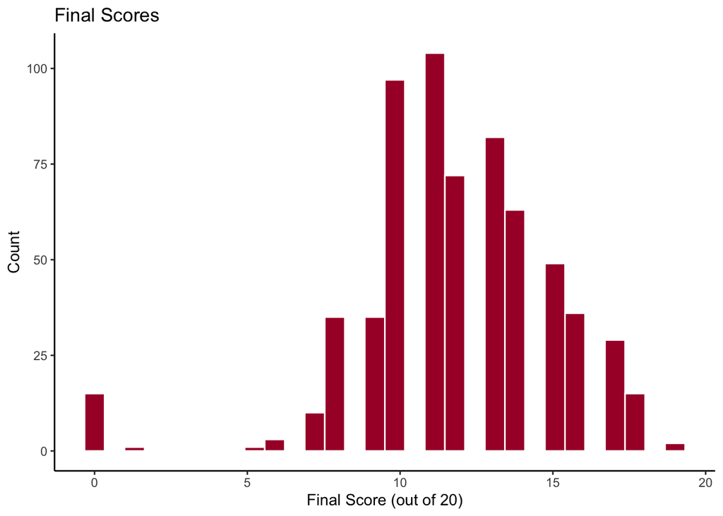

```r
df |>
    ggplot(
        aes(x = g3)
    ) +
    geom_histogram(
        fill = '#A90533',
        color = 'white'
    ) +
    theme_classic() +
    labs(
        title = 'Final Scores',
        x = 'Final Score (out of 20)',
        y = 'Count'
    )
```

To visualize the final scores by `address` type, we use the boxplot.

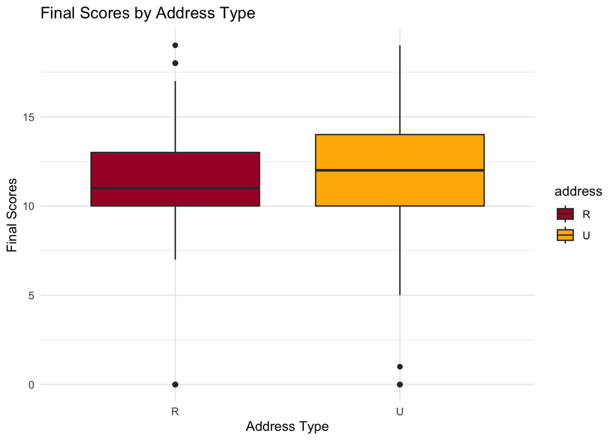

```r
df |>
    ggplot(
        aes(
            x = address,
            y = g3,
            fill = address
        )
    ) +
    geom_boxplot() +
    theme_minimal() +
    labs(
        title = 'Final Scores by Address Type',
        x = 'Address Type',
        y = 'Final Scores'
    ) +
    scale_fill_manual(values = c('#A90533', '#FFB500')) #manually change the colors of the boxes; #A90533 and #FFB500 are the official primary colors of Flagler College
```

### 6.2 Question 2

Since `studytime` and `g3` are both continuous and numeric under the assumption made in the research questions section. The appropriate visualization for this question is the scatter plot.

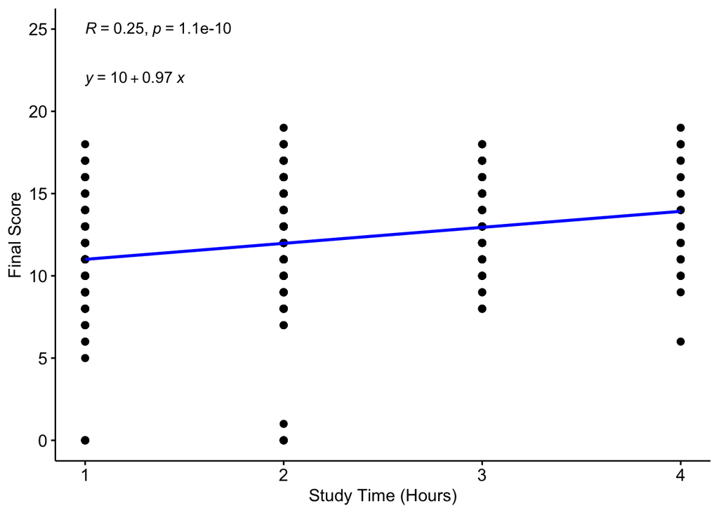

```r
ggscatter(
    df,
    x = 'studytime',
    y = 'g3',
    add = 'reg.line',
    add.params = list(color = 'blue'),
    xlab = 'Study Time (Hours)',
    ylab = 'Final Score'
) +
    stat_cor(
        label.x = 1,
        label.y = 25
    ) +
    stat_regline_equation(
        label.x = 1,
        label.y = 22,
    )
```

## 7 Statistical tests

### 7.1 Question 1

$H_0$: $\mu_R = \mu_U$  
$H_a$: $\mu_R \ne \mu_U$

```r
test_1 <- t.test(
    g3 ~ address,
    data = df
)

test_1
```

```
    Welch Two Sample t-test

data:  g3 by address
t = -4.0199, df = 318.49, p-value = 7.274e-05
alternative hypothesis: true difference in means between group R and group U is not equal to 0
95 percent confidence interval:
 -1.7530260 -0.6009338
sample estimates:
mean in group R mean in group U
       11.08629        12.26327
```

The $p$-value is $p = 7.2738534\times 10^{-5} < 0.05$, so we reject the null hypothesis that the mean final scores are the same.

### 7.2 Question 2

Note that `ggpubr` gave us the necessary statistical outputs for the regression analysis between `studytime` and final score (`g3`). We have the $p$-value of $p = 1.1 \times 10^{-10} < 0.05$. The correlation coefficient $R = 0.25$ with the regression equation $y = 10 + 0.97x$, where $x$ is `studytime` and $y$ is the final score (`g3`).